# Analysing steps per day

```r
library(dplyr)
```

```r
library(ggplot2)
library(lubridate)
```

This is a document for the Peer Assessmentof the Reproducible Research course from coursera.

```r
data <-  read.csv(file = "activity.csv", stringsAsFactors = FALSE)
original_data <- data
```

We got only the complete cases

```r
data <- data[complete.cases(data),]
data$date <- as.Date(data$date)
```

Afeter processing data with dplyr we can show the total steps per day:

```r
data_total_steps <- select(data, steps, date) %>%
                  group_by(date) %>%
                  summarise(sum_steps_day = sum(steps) )

data_total_steps
```

```
## Source: local data frame [53 x 2]
##
##          date sum_steps_day
## 1  2012-10-02           126
## 2  2012-10-03         11352
## 3  2012-10-04         12116
## 4  2012-10-05         13294
## 5  2012-10-06         15420
## 6  2012-10-07         11015
## 7  2012-10-09         12811
## 8  2012-10-10          9900
## 9  2012-10-11         10304
## 10 2012-10-12         17382
## ..        ...           ...
```

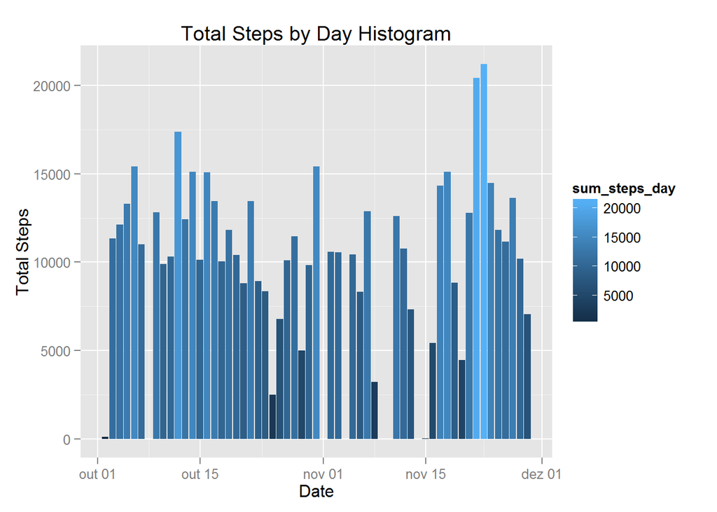

```r
ggplot(data=data_total_steps, aes(x=date, y=sum_steps_day, fill=sum_steps_day)) +
    geom_histogram(stat="identity") +
    xlab("Date") + ylab("Total Steps") +
    ggtitle("Total Steps by Day Histogram")
```

We calculate the mean and the median for the data.

```r
data_mean_median_steps <- select(data, steps, date) %>%
                            group_by(date) %>%
                            summarise(mean_steps_day = mean(steps), median_steps_day = median(steps) )


data_mean_median_steps
```

```
## Source: local data frame [53 x 3]
##
##          date mean_steps_day median_steps_day
## 1  2012-10-02        0.43750                0
## 2  2012-10-03       39.41667                0
## 3  2012-10-04       42.06944                0
## 4  2012-10-05       46.15972                0
## 5  2012-10-06       53.54167                0
## 6  2012-10-07       38.24653                0
## 7  2012-10-09       44.48264                0
## 8  2012-10-10       34.37500                0
## 9  2012-10-11       35.77778                0
## 10 2012-10-12       60.35417                0
## ..        ...            ...              ...
```

Now we´ll prepare the data to calculate the avarage number of steps grouped by 5-minute interval:

```r
data_5_minutes_interval <- group_by(data, interval) %>%
                            summarise(mean_steps = mean(steps))

data_5_minutes_interval
```

```
## Source: local data frame [288 x 2]
##
##    interval mean_steps
## 1         0  1.7169811
## 2         5  0.3396226
## 3        10  0.1320755
## 4        15  0.1509434
## 5        20  0.0754717
## 6        25  2.0943396
## 7        30  0.5283019
## 8        35  0.8679245
## 9        40  0.0000000
## 10       45  1.4716981
## ..      ...        ...
```

Let´s just put it into a time series plot.

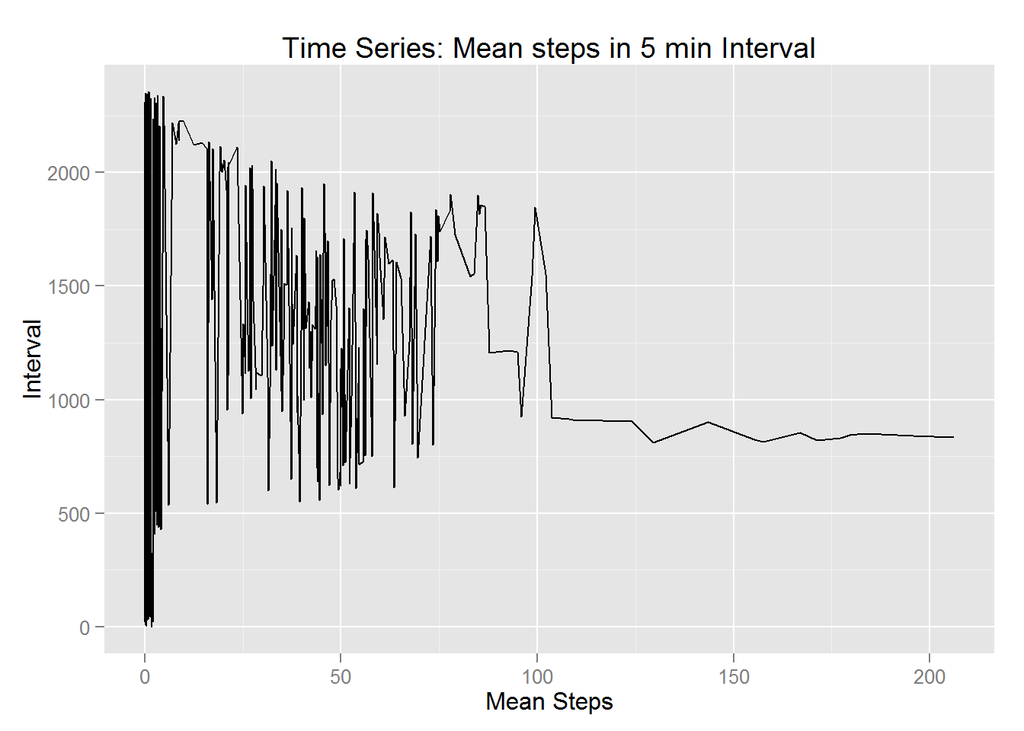

```r
ggplot(data_5_minutes_interval, aes(x = mean_steps, y = interval)) +
    geom_line() +
    xlab("Mean Steps") + ylab("Interval") +
    ggtitle("Time Series: Mean steps in 5 min Interval")
```

Until now we used only the complete cases, but let´s do something different.

Let´s calculate the total missing values:

```r
missing_values <- sum(!complete.cases(original_data))
missing_values
```

```
## [1] 2304
```

We choosed to fill those lines with the mean of total steps

```r
mean_steps <- mean(data$steps)

original_data[!complete.cases(original_data), 1] <- mean_steps
```

Let´s so calculate the new value of total steps:

```r
original_data_total_steps <- select(original_data, steps, date) %>%
                  group_by(date) %>%
                  summarise(sum_steps_day = sum(steps) )

original_data_total_steps
```

```
## Source: local data frame [61 x 2]
##
##          date sum_steps_day
## 1  2012-10-01      10766.19
## 2  2012-10-02        126.00
## 3  2012-10-03      11352.00
## 4  2012-10-04      12116.00
## 5  2012-10-05      13294.00
## 6  2012-10-06      15420.00
## 7  2012-10-07      11015.00
## 8  2012-10-08      10766.19
## 9  2012-10-09      12811.00
## 10 2012-10-10       9900.00
## ..        ...           ...
```

Now let´s see it in a histogram:

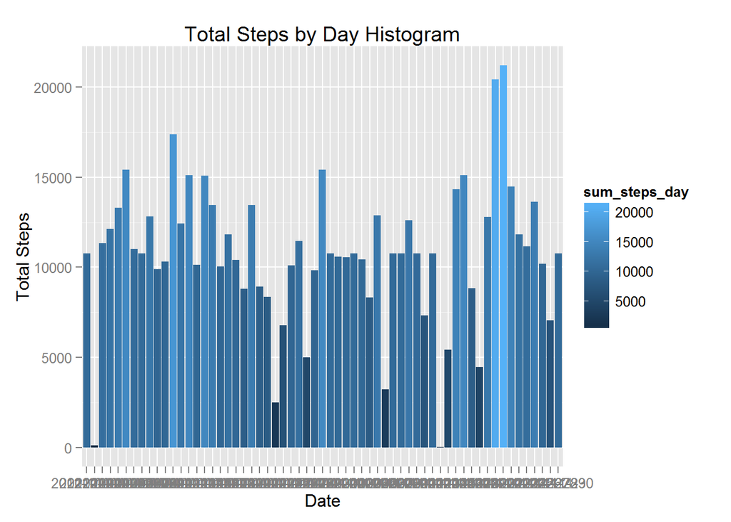

```r
ggplot(data=original_data_total_steps, aes(x=date, y=sum_steps_day, fill=sum_steps_day)) +
    geom_histogram(stat="identity") +
    xlab("Date") + ylab("Total Steps") +
    ggtitle("Total Steps by Day Histogram")
```

And calculate the mean and the median for the data.

```r
original_data_mean_median_steps <- select(original_data, steps, date) %>%
                            group_by(date) %>%
                            summarise(mean_steps_day = mean(steps), median_steps_day = median(steps) )


original_data_mean_median_steps
```

```
## Source: local data frame [61 x 3]
##
##          date mean_steps_day median_steps_day
## 1  2012-10-01       37.38260          37.3826
## 2  2012-10-02        0.43750           0.0000
## 3  2012-10-03       39.41667           0.0000
## 4  2012-10-04       42.06944           0.0000
## 5  2012-10-05       46.15972           0.0000
## 6  2012-10-06       53.54167           0.0000
## 7  2012-10-07       38.24653           0.0000
## 8  2012-10-08       37.38260          37.3826
## 9  2012-10-09       44.48264           0.0000
## 10 2012-10-10       34.37500           0.0000
## ..        ...            ...              ...
```

As we can see there were missing blocs in the first histogram that now were filled.

Now let´s see f thereare differences between weekends and weekdays.

We´ll now create a new table with one more variables, that will be a factor with two levels “weekday” and “weekend”, lets name it type_day.

As I´m brazlian, the weekend days are named “sábado” and “domingo”, equivalent to “saturday” and “sunday”.

```r
original_data_weekdays <- mutate(original_data,
                                          type_day = ifelse(weekdays(as.Date(date)) == "sábado"
                                                            | weekdays(as.Date(date)) == "domingo",
                                                            "weekend", "weekday")) %>%
                                  mutate(type_day = as.factor(type_day))
```

Now let´s make a time series plot of the mean steps taken in determined interval on weekends and weekdays:

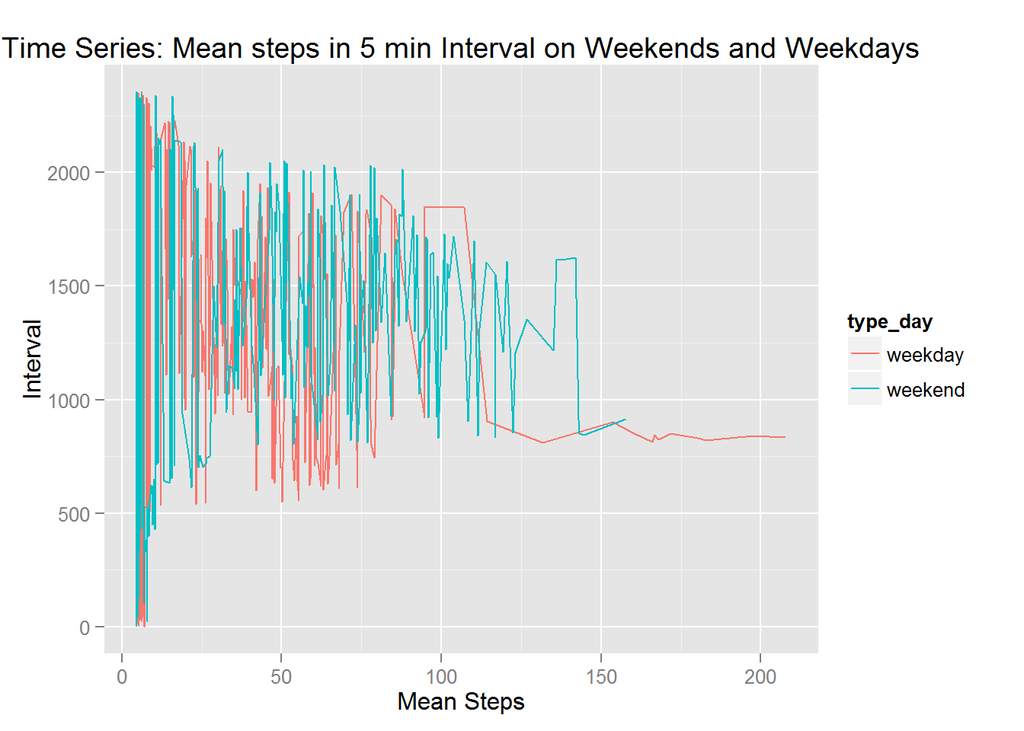

```r
original_data_5_min_weekdays <- group_by(original_data_weekdays, interval, type_day) %>%
                                summarise(mean_steps = mean(steps))


ggplot(original_data_5_min_weekdays, aes(x = mean_steps, y = interval, fill = type_day, color = type_day)) +
    geom_line() +
    xlab("Mean Steps") + ylab("Interval") +
    ggtitle("Time Series: Mean steps in 5 min Interval on Weekends and Weekdays")
```